# BI_STAT_2021 Project_3

24/02/2021

# 1 Описание датасета

## 1.1 Предобработка данных

```r
mouse_data <- read_xls('C:/Users/maxim/Desktop/Statistiks-and-R-programming/data/Data_Cortex_Nuclear.xls')
```

## 1.2 Количество измерений

Согласно описанию датасета, в экспериментах было зарегистрировано 15 измерений каждого белка на образец / мышь. То есть чтобы понять, сколько мышей было в эксперименте, необходимо поделить на 15 число всех строк, так как на каждую уникальную мышь имеется 15 отдельных измерений.

```r
number_of_mouses <- nrow(mouse_data)/15
```

Получается, что в экспериментах приняло участие 72 мыши, что согласуется с описанием датасета.

## 1.3 Выделенные группы

Ознакомившись с дальнейшим описанием датасете, можно узнать, что мыши условно разбиваются на 8 классов, на основании генотипа (контрольные (с) или трисомные (t) мыши), поведения(мыши, стимулированные к обучению (CS) и нет (SC)) и лечения(мемантин (m) или салин (s)). Информация о классе мыши содержится в последнем столбце датасета. Посмотрим распределение мышей по группам, составив таблицу (не забыв поделить на 15).

```r
aggregate(cbind(count = MouseID) ~ class,
          data = mouse_data,
          FUN = function(x){NROW(x)/15})
```

```
##    class count
## 1 c-CS-m    10
## 2 c-CS-s     9
## 3 c-SC-m    10
## 4 c-SC-s     9
## 5 t-CS-m     9
## 6 t-CS-s     7
## 7 t-SC-m     9
## 8 t-SC-s     9
```

Из этой таблицы можно понять, что, например, трисомных мышей, которых стимулировали к обучению и подвергали стимуляции мемантином в данном эксперименте было 9. Видим, что в целом представителей каждой из групп примерно поровну, то есть группы действительно достаточно сбалансированы.

## 1.4 Количество полных наблюдений

Посчитаем количество полных наблюдений, то есть количество тех измерений, для которых есть данные по экпрессии всех белков, без пропущенных значений.

```r
data_without_NA <- na.omit(mouse_data)
number_of_data_without_NA <- nrow(na.omit(mouse_data))
```

# 2 Различия в уровне продукции BDNF_N

Для того, что проверить есть ли различия в уровне продукции данного белка в зависимости от класса, рассмотрим датафрейм без пропущенных значений экспрессии белка BDNF_N. Далее построим боксплоты для каждого класса и визуально оценим различия в экспрессии.

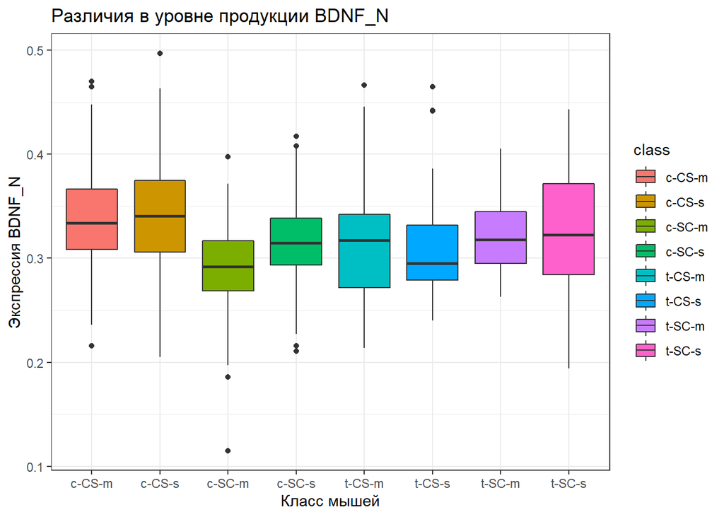

```r
ggplot(mouse_data[!(is.na(mouse_data$BDNF_N)), ], aes(x=class, y=BDNF_N, fill=class))+
  geom_boxplot()+
  xlab("Класс мышей")+
  ylab("Экспрессия BDNF_N")+
  ggtitle("Различия в уровне продукции BDNF_N")+
  theme_bw()
```

Кажется, что мы действительно имеем некоторые значимые различия между первыми двумя классами и остальными. Однако, по данному графику мы не можем судить, от чего именно зависит продукция BFNF_N. В данном случае мы имеем 8 классов, созданных по 3 независимым признакам. Если мы хотим изучить, от чего именно меняется экспрессия данного белка, нам надо провести более подробный анализ, и выяснить, меняется ли экспрессия от какого-нибудь одного признака (например, от вида лечения) или от некоторой совокупности признаков. Для этого используем дисперсионный анализ, а затем проведем пост-хок тесты.

```r
mouse_data$class <- as.factor(mouse_data$class)
model <- lm(BDNF_N ~ class, data = mouse_data)
a_model <- Anova(mod = model)
```

Однако, необходимо проверить рассматриваемые переменные на условия применимости дисперсионного анализа, а именно:

- нормальное распределение остатков
- гомогенность дисперсий остатков
- отсутствие коллинеарности (независимость групп)
- случайность и независимость наблюдений в группах

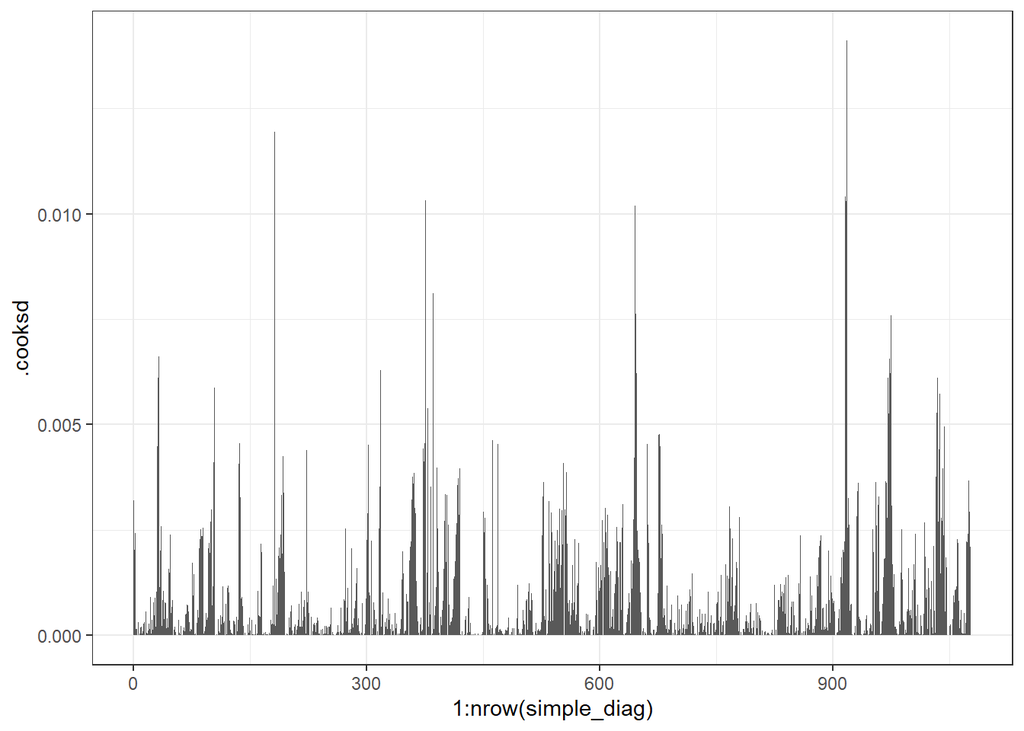

```r
simple_diag <- fortify(model)

ggplot(simple_diag, aes(x = 1:nrow(simple_diag), y = .cooksd)) +
  geom_bar(stat = 'identity')
```

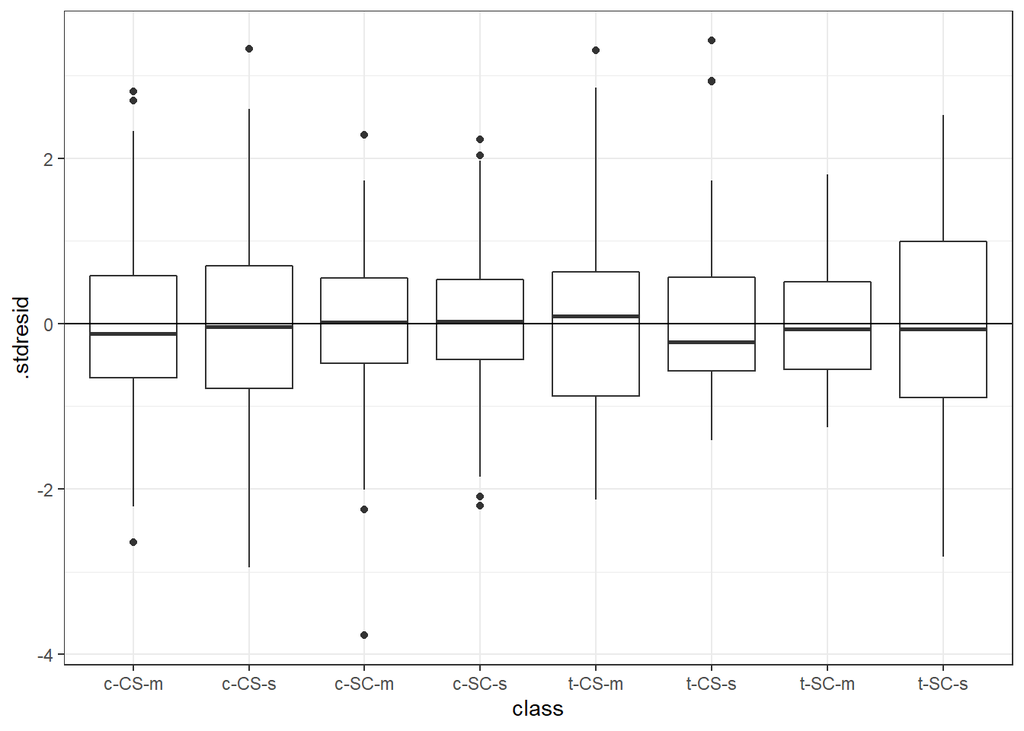

```r
ggplot(data = simple_diag, aes(x = class, y = .stdresid)) +
  geom_boxplot() + geom_hline(yintercept = 0)
```

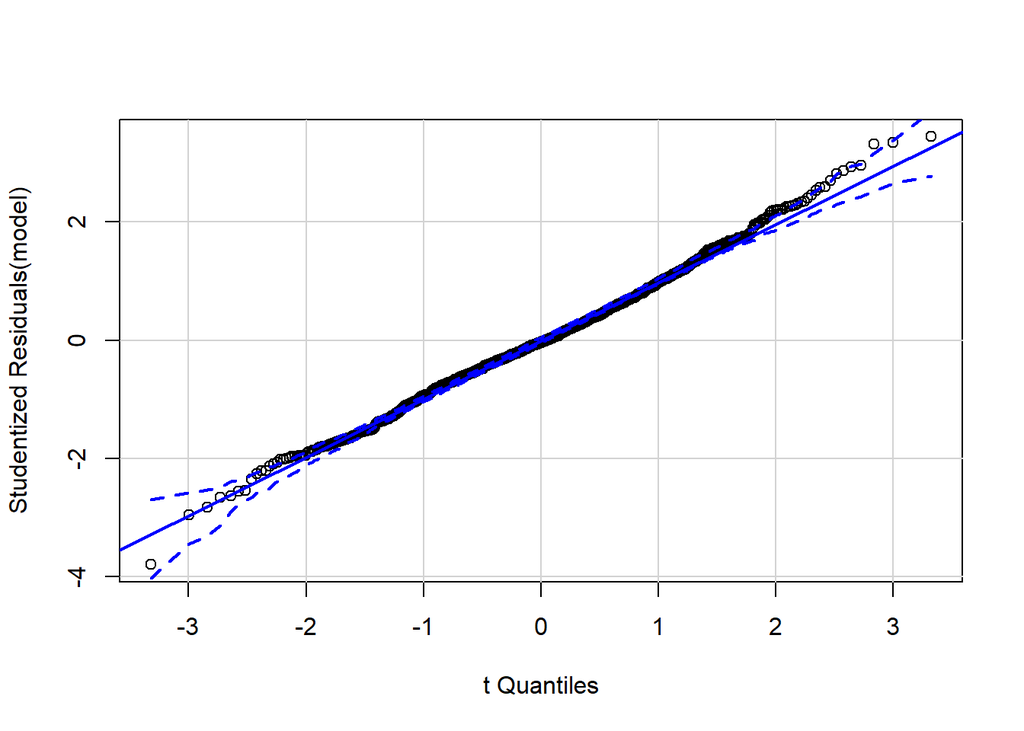

```r
qqPlot(model, id = FALSE)
```

В итоге, согласно всем проверкам мы действительно можем применить дисперсионный анализ. Посмотрим на его результаты.

```r
a_model
```

```
## Anova Table (Type II tests)
##
## Response: BDNF_N
##            Sum Sq   Df F value    Pr(>F)
## class     0.28784    7  18.816 < 2.2e-16 ***
## Residuals 2.33619 1069
## ---
## Signif. codes:  0 '***' 0.001 '**' 0.01 '*' 0.05 '.' 0.1 ' ' 1
```

По результатам дисперсионного анализа класс мыши значимо влияет на экспрессию белка BDNF_N (F = 18.816, p_value = 2.2e-16, Df = 7). Для того, чтобы определить как именно класс влияет на экспрессию белка проведем пост-хок тесты.

```r
dat_tukey <- glht(model, linfct = mcp(class= 'Tukey'))
summary(dat_tukey)
```

```
##
##   Simultaneous Tests for General Linear Hypotheses
##
## Multiple Comparisons of Means: Tukey Contrasts
##
##
## Fit: lm(formula = BDNF_N ~ class, data = mouse_data)
##
## Linear Hypotheses:
##                        Estimate Std. Error t value Pr(>|t|)
## c-CS-s - c-CS-m == 0  0.0030979  0.0055459   0.559  0.99930
## c-SC-m - c-CS-m == 0 -0.0482717  0.0053980  -8.942  < 0.001 ***
## c-SC-s - c-CS-m == 0 -0.0258249  0.0055459  -4.657  < 0.001 ***
## t-CS-m - c-CS-m == 0 -0.0264852  0.0055459  -4.776  < 0.001 ***
## t-CS-s - c-CS-m == 0 -0.0337570  0.0059483  -5.675  < 0.001 ***
## t-SC-m - c-CS-m == 0 -0.0181541  0.0055459  -3.273  0.02439 *
## t-SC-s - c-CS-m == 0 -0.0136310  0.0055790  -2.443  0.22122
## c-SC-m - c-CS-s == 0 -0.0513696  0.0055459  -9.263  < 0.001 ***
## c-SC-s - c-CS-s == 0 -0.0289228  0.0056900  -5.083  < 0.001 ***
## t-CS-m - c-CS-s == 0 -0.0295831  0.0056900  -5.199  < 0.001 ***
## t-CS-s - c-CS-s == 0 -0.0368549  0.0060829  -6.059  < 0.001 ***
## t-SC-m - c-CS-s == 0 -0.0212520  0.0056900  -3.735  0.00495 **
## t-SC-s - c-CS-s == 0 -0.0167289  0.0057223  -2.923  0.06849 .
## c-SC-s - c-SC-m == 0  0.0224468  0.0055459   4.047  0.00132 **
## t-CS-m - c-SC-m == 0  0.0217865  0.0055459   3.928  0.00234 **
## t-CS-s - c-SC-m == 0  0.0145147  0.0059483   2.440  0.22233
## t-SC-m - c-SC-m == 0  0.0301176  0.0055459   5.431  < 0.001 ***
## t-SC-s - c-SC-m == 0  0.0346406  0.0055790   6.209  < 0.001 ***
## t-CS-m - c-SC-s == 0 -0.0006603  0.0056900  -0.116  1.00000
## t-CS-s - c-SC-s == 0 -0.0079321  0.0060829  -1.304  0.89717
## t-SC-m - c-SC-s == 0  0.0076708  0.0056900   1.348  0.87968
## t-SC-s - c-SC-s == 0  0.0121939  0.0057223   2.131  0.39499
## t-CS-s - t-CS-m == 0 -0.0072718  0.0060829  -1.195  0.93314
## t-SC-m - t-CS-m == 0  0.0083311  0.0056900   1.464  0.82601
## t-SC-s - t-CS-m == 0  0.0128542  0.0057223   2.246  0.32456
## t-SC-m - t-CS-s == 0  0.0156029  0.0060829   2.565  0.16952
## t-SC-s - t-CS-s == 0  0.0201260  0.0061130   3.292  0.02269 *
## t-SC-s - t-SC-m == 0  0.0045231  0.0057223   0.790  0.99359
## ---
## Signif. codes:  0 '***' 0.001 '**' 0.01 '*' 0.05 '.' 0.1 ' ' 1
## (Adjusted p values reported -- single-step method)
```

Для наглядности, визуализируем этот результат.

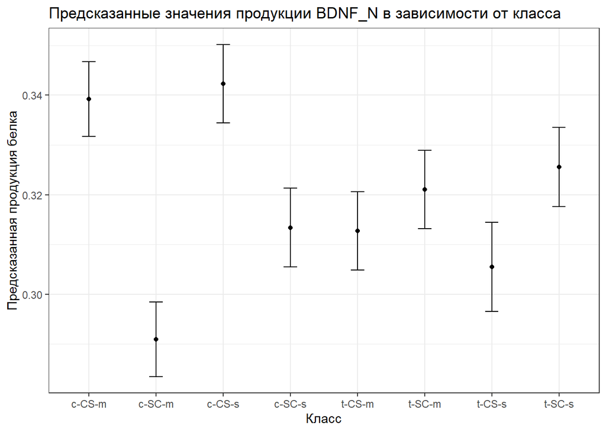

```r
MyData <-  expand.grid(class = data_without_NA$class)
MyData <- data.frame(MyData,
                   predict(model, newdata = MyData, interval = 'confidence'))
pos <- position_dodge(width = 0.2)
gg_linep <- ggplot(data = MyData, aes(x = class, y = fit,
                             ymin = lwr, ymax = upr)) +
  geom_point(position = pos) +
  geom_errorbar(position = pos, width = 0.2) +
  xlab('Класс') +
  ylab('Предсказанная продукция белка') +
  ggtitle('Предсказанные значения продукции BDNF_N в зависимости от класса')
gg_linep
```

# 3 Линейная модель для предсказании продукции белка ERBB4_N в зависимости от продукции других белков

Исследуем, окажется ли удачной построение полной линейной модели для предсказания продукции ERBB4_N. Для этого возьмем датасет без пропущенных данных, в котором так же оставим только данные о продукции других белков.

```r
ERBB4_mod <- lm(ERBB4_N ~ ., data = mouse_data[, -c(1, 79, 80, 81, 82)])
```

Произведем необходимый анализ с помощью функции fortify() из пакета ggplot.

```r
mod_diag <- fortify(ERBB4_mod)
head(mod_diag)
```

```
##      ERBB4_N  DYRK1A_N   ITSN1_N    BDNF_N    NR1_N   NR2A_N    pAKT_N
## 76 0.1611201 0.6497813 0.8286964 0.4058618 2.921435 5.167979 0.2071741
## 77 0.1615293 0.6164807 0.8419742 0.3885837 2.862575 5.194163 0.2234335
## 78 0.1810336 0.6374243 0.8528818 0.4005615 2.968155 5.350820 0.2087902
## 79 0.1636318 0.5768145 0.7553900 0.3483463 2.624901 4.727509 0.2058923
## 80 0.1679717 0.5425448 0.7579173 0.3500507 2.634509 4.735602 0.2105263
## 81 0.1779682 0.5699176 0.7610777 0.3439100 2.598085 4.764640 0.2039635
##      pBRAF_N pCAMKII_N   pCREB_N   pELK_N    pERK_N    pJNK_N    PKCA_N
## 76 0.1766404  3.728084 0.2392826 1.666579 0.9694663 0.3212598 0.4065617
## 77 0.1677253  3.648240 0.2210300 1.565150 0.9918455 0.3429185 0.3969099
## 78 0.1732608  3.814545 0.2223002 1.741732 0.9899991 0.3289762 0.3979296
## 79 0.1611920  3.778530 0.1941528 1.505475 0.8191669 0.3115476 0.3858223
## 80 0.1656711  3.871971 0.1942973 1.531613 0.8150569 0.3150006 0.3915249
## 81 0.1644400  3.843465 0.1930528 1.575707 0.8364507 0.3065019 0.3737475
##       pMEK_N    pNR1_N   pNR2A_N  pNR2B_N pPKCAB_N    pRSK_N     AKT_N
```

[output cut: 69 more lines]

## 3.1 Проверка независимости наблюдений.

```r
durbinWatsonTest(ERBB4_mod)
```

```
##  lag Autocorrelation D-W Statistic p-value
##    1      0.06552646      1.866165       0
##  Alternative hypothesis: rho != 0
```

В данном случае значение критерия Дарбина-Уотсона меньше 2, то есть присутствует положительная автокорреляция. Значит, мы не можем сказать, что наблюдения в данном случае независимые.

## 3.2 Проверка линейности взаимодействий и постоянства дисперсии. График остатков модели от предсказанных значений.

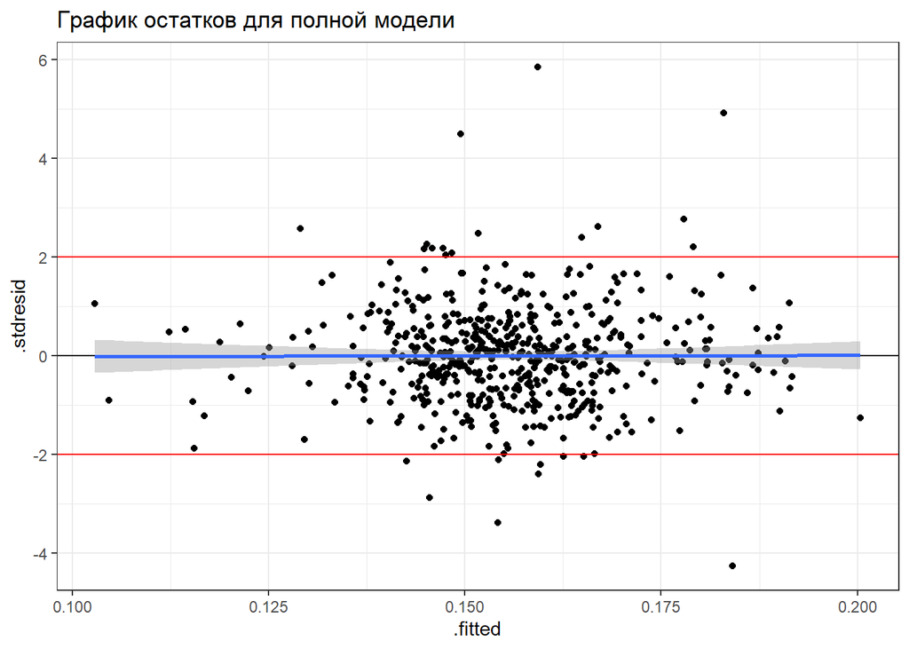

```r
gg_resid <- ggplot(data = mod_diag, aes(x = .fitted, y = .stdresid)) +
  geom_point() +
  geom_hline(yintercept = 0)+
  geom_smooth(method = "lm") +
  geom_hline(yintercept = 2, color = "red") +
  geom_hline(yintercept = -2, color = "red") +
  ggtitle("График остатков для полной модели")
gg_resid
```

В данном случае не очень много точек выбивается за пределы +/- 2 стандартных отклонений, то есть можно говорить, что нет больших проблем с линейностью взаимосвязи. Однако, на графике остатков наблюдается некоторая гетоскедактичность.

## 3.3 Проверка влиятельных наблюдений. График расстояний Кука.

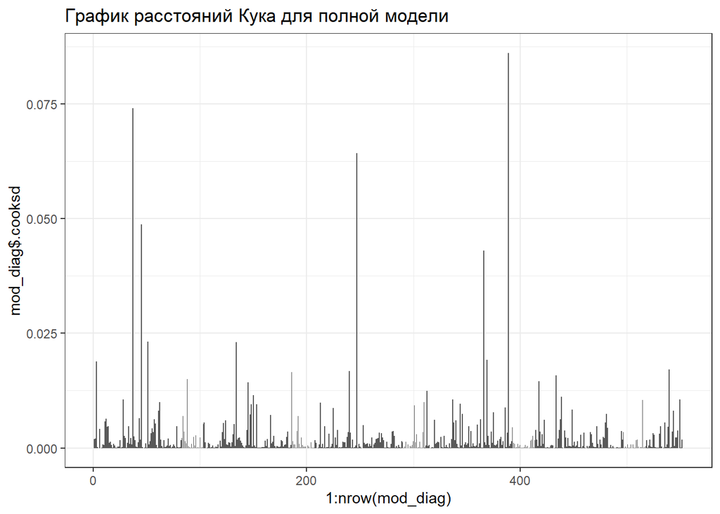

```r
ggplot(mod_diag, aes(x = 1:nrow(mod_diag), y = mod_diag$.cooksd)) +
  geom_bar(stat = "identity")+
  ggtitle("График расстояний Кука для полной модели")
```

Нельзя однозначно судить о присутствии большого числа влиятельных наблюдений.

## 3.4 Проверка на нормальность распеределения. График QQ-plot.

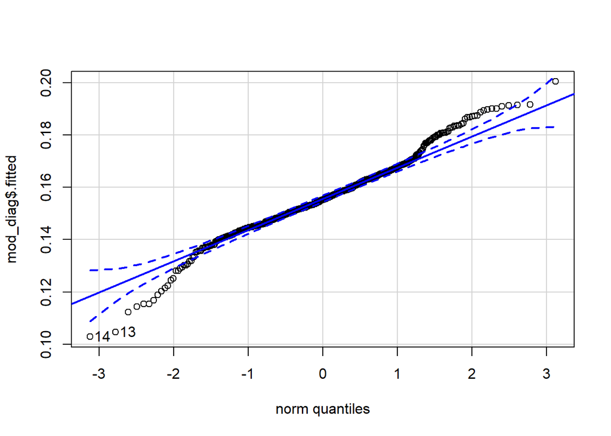

```
## [1] 14 13
```

```r
qqPlot(mod_diag$.fitted)
```

## 3.5 Проверка на мультиколлениарность

При попытке проверки модели на мультиколлениарность функцией vif возникают проблем с “идеальной мультиколлениарностью”, то есть с переменными, которые линейно зависят от других. Посмотрев, с чем возникает проблема с помощью функции alias, уберем эти переменные из модели.

```r
alias(ERBB4_mod)
```

```
## Model :
## ERBB4_N ~ DYRK1A_N + ITSN1_N + BDNF_N + NR1_N + NR2A_N + pAKT_N +
##     pBRAF_N + pCAMKII_N + pCREB_N + pELK_N + pERK_N + pJNK_N +
##     PKCA_N + pMEK_N + pNR1_N + pNR2A_N + pNR2B_N + pPKCAB_N +
##     pRSK_N + AKT_N + BRAF_N + CAMKII_N + CREB_N + ELK_N + ERK_N +
##     GSK3B_N + JNK_N + MEK_N + TRKA_N + RSK_N + APP_N + Bcatenin_N +
##     SOD1_N + MTOR_N + P38_N + pMTOR_N + DSCR1_N + AMPKA_N + NR2B_N +
##     pNUMB_N + RAPTOR_N + TIAM1_N + pP70S6_N + NUMB_N + P70S6_N +
##     pGSK3B_N + pPKCG_N + CDK5_N + S6_N + ADARB1_N + AcetylH3K9_N +
##     RRP1_N + BAX_N + ARC_N + nNOS_N + Tau_N + GFAP_N + GluR3_N +
##     GluR4_N + IL1B_N + P3525_N + pCASP9_N + PSD95_N + SNCA_N +
##     Ubiquitin_N + pGSK3B_Tyr216_N + SHH_N + BAD_N + BCL2_N +
##     pS6_N + pCFOS_N + SYP_N + H3AcK18_N + EGR1_N + H3MeK4_N +
##     CaNA_N
##
## Complete :
##       (Intercept) DYRK1A_N ITSN1_N BDNF_N NR1_N NR2A_N pAKT_N pBRAF_N pCAMKII_N
## pS6_N 0           0        0       0      0     0      0      0       0
##       pCREB_N pELK_N pERK_N pJNK_N PKCA_N pMEK_N pNR1_N pNR2A_N pNR2B_N
## pS6_N 0       0      0      0      0      0      0      0       0
##       pPKCAB_N pRSK_N AKT_N BRAF_N CAMKII_N CREB_N ELK_N ERK_N GSK3B_N JNK_N
## pS6_N 0        0      0     0      0        0      0     0     0       0
##       MEK_N TRKA_N RSK_N APP_N Bcatenin_N SOD1_N MTOR_N P38_N pMTOR_N DSCR1_N
## pS6_N 0     0      0     0     0          0      0      0     0       0
##       AMPKA_N NR2B_N pNUMB_N RAPTOR_N TIAM1_N pP70S6_N NUMB_N P70S6_N pGSK3B_N
## pS6_N 0       0      0       0        0       0        0      0       0
##       pPKCG_N CDK5_N S6_N ADARB1_N AcetylH3K9_N RRP1_N BAX_N ARC_N nNOS_N Tau_N
## pS6_N 0       0      0    0        0            0      0     1     0      0
##       GFAP_N GluR3_N GluR4_N IL1B_N P3525_N pCASP9_N PSD95_N SNCA_N Ubiquitin_N
## pS6_N 0      0       0       0      0       0        0       0      0
##       pGSK3B_Tyr216_N SHH_N BAD_N BCL2_N pCFOS_N SYP_N H3AcK18_N EGR1_N
## pS6_N 0               0     0     0      0       0     0         0
##       H3MeK4_N CaNA_N
## pS6_N 0        0
```

```r
new_ERBB4_mod <- update(ERBB4_mod, .~. - pS6_N)
vif(new_ERBB4_mod)
```

```
##        DYRK1A_N         ITSN1_N          BDNF_N           NR1_N          NR2A_N
##       23.736607       59.473637       16.669610       96.311682       25.127918
##          pAKT_N         pBRAF_N       pCAMKII_N         pCREB_N          pELK_N
##       21.880134        9.671403       19.251803       17.421324        2.584965
##          pERK_N          pJNK_N          PKCA_N          pMEK_N          pNR1_N
##       55.739024       26.508561       38.653895       23.634116       44.380168
##         pNR2A_N         pNR2B_N        pPKCAB_N          pRSK_N           AKT_N
##       33.053974       55.826515       33.036076       15.913962       17.993694
##          BRAF_N        CAMKII_N          CREB_N           ELK_N           ERK_N
##       41.690503       16.062122        9.992444       29.844699       55.249434
##         GSK3B_N           JNK_N           MEK_N          TRKA_N           RSK_N
##       32.819856       18.997732       15.629309       72.480935       16.236937
##           APP_N      Bcatenin_N          SOD1_N          MTOR_N           P38_N
##       21.563500       91.994091       20.108411       17.860768       19.953844
##         pMTOR_N         DSCR1_N         AMPKA_N          NR2B_N         pNUMB_N
##       17.905757       14.567686       27.108067       11.017845       20.067495
##        RAPTOR_N         TIAM1_N        pP70S6_N          NUMB_N         P70S6_N
##       19.127590       21.793679        9.784679       23.482651       13.516220
##        pGSK3B_N         pPKCG_N          CDK5_N            S6_N        ADARB1_N
##       12.102837       22.052092        2.976573       17.503666        9.335931
##    AcetylH3K9_N          RRP1_N           BAX_N           ARC_N          nNOS_N
##       42.778299        1.716449        8.071101       14.624584        9.589675
##           Tau_N          GFAP_N         GluR3_N         GluR4_N          IL1B_N
##       17.829428        5.422842       10.719066        8.004983        9.575112
##         P3525_N        pCASP9_N         PSD95_N          SNCA_N     Ubiquitin_N
##        7.896508        9.082792       14.501625        9.291047       10.532632
## pGSK3B_Tyr216_N           SHH_N           BAD_N          BCL2_N         pCFOS_N
##       11.355079        5.101022       13.413137        8.480518        6.364879
##           SYP_N       H3AcK18_N          EGR1_N        H3MeK4_N          CaNA_N
##        9.429731       36.335690       13.981307       15.299243       19.739341
```

Как итог, полная модель не является корректной, так как:

- распределение не является нормальным;
- присутствует автокорреляция;
- вероятно наблюдаются проблемы с наличием влиятельных наблюдений;
- многие предикторы зависимы друг от друга, то есть имеются проблемы с мультиколлениарностью.

Последняя проблема наиболее значительная, показатель vif для огромного числа параметров очень большой. Вероятно, это связано с особенностями данных - в биологии часто экспрессия одного белка действительно напрямую зависит от другого, в случае, например, белков-регуляторов. Соответственно, из-за большого числа рассматриваемых параметров и мультиколлениарности между ними, линейная модель для данного случая не явлется удачным решением. Для более корректной работы необходимо уменьшить число переменных путем выполнения РСА.

# 4 РСА

```r
mouse_data_num <- data_without_NA %>% select_if(is.numeric)
mouse_pca <- rda(mouse_data_num, scale = TRUE)
head(summary(mouse_pca))
```

```
##
## Call:
## rda(X = mouse_data_num, scale = TRUE)
##
## Partitioning of correlations:
##               Inertia Proportion
## Total              77          1
## Unconstrained      77          1
##
## Eigenvalues, and their contribution to the correlations
##
## Importance of components:
##                           PC1     PC2     PC3     PC4     PC5     PC6     PC7
## Eigenvalue            23.0488 13.3587 7.58646 7.16154 3.28242 3.04234 2.36733
## Proportion Explained   0.2993  0.1735 0.09853 0.09301 0.04263 0.03951 0.03074
## Cumulative Proportion  0.2993  0.4728 0.57135 0.66436 0.70699 0.74650 0.77724
##                           PC8     PC9    PC10    PC11    PC12    PC13     PC14
## Eigenvalue            2.25528 1.83075 1.27872 1.11166 0.98313 0.86294 0.700922
## Proportion Explained  0.02929 0.02378 0.01661 0.01444 0.01277 0.01121 0.009103
## Cumulative Proportion 0.80653 0.83031 0.84691 0.86135 0.87412 0.88533 0.894428
##                           PC15     PC16     PC17     PC18     PC19     PC20
## Eigenvalue            0.611169 0.569217 0.520420 0.484876 0.418534 0.399046
## Proportion Explained  0.007937 0.007392 0.006759 0.006297 0.005436 0.005182
## Cumulative Proportion 0.902366 0.909758 0.916517 0.922814 0.928249 0.933432
##                           PC21     PC22     PC23     PC24     PC25     PC26
## Eigenvalue            0.387367 0.339991 0.319123 0.292254 0.259013 0.241727
## Proportion Explained  0.005031 0.004415 0.004144 0.003796 0.003364 0.003139
## Cumulative Proportion 0.938462 0.942878 0.947022 0.950818 0.954182 0.957321
##                           PC27    PC28     PC29     PC30     PC31     PC32
## Eigenvalue            0.216222 0.20709 0.182731 0.166772 0.150604 0.136755
## Proportion Explained  0.002808 0.00269 0.002373 0.002166 0.001956 0.001776
## Cumulative Proportion 0.960129 0.96282 0.965192 0.967358 0.969314 0.971090
##                           PC33     PC34     PC35     PC36     PC37    PC38
## Eigenvalue            0.133922 0.124826 0.123532 0.112486 0.105178 0.09622
## Proportion Explained  0.001739 0.001621 0.001604 0.001461 0.001366 0.00125
## Cumulative Proportion 0.972829 0.974450 0.976054 0.977515 0.978881 0.98013
##                           PC39     PC40     PC41     PC42      PC43      PC44
## Eigenvalue            0.091371 0.091173 0.082556 0.079101 0.0734032 0.0725823
## Proportion Explained  0.001187 0.001184 0.001072 0.001027 0.0009533 0.0009426
## Cumulative Proportion 0.981317 0.982501 0.983574 0.984601 0.9855541 0.9864968
```

[output cut: 42 more lines]

```
## NR2A_N   -1.3164 -0.3703  0.56759  0.2723 -0.02731  0.04109
## pAKT_N   -1.0192  0.8742 -0.23253 -0.6059 -0.35846  0.03465
## ....
##
##
## Site scores (weighted sums of species scores)
##
##          PC1     PC2       PC3    PC4    PC5    PC6
## sit1 -0.7976 -0.5826  0.143685 0.5628 0.8218 0.3433
## sit2 -0.7412 -0.4971  0.058363 0.6059 1.0285 0.4438
## sit3 -0.8751 -0.5060  0.110153 0.4895 1.0174 0.3225
## sit4 -0.3027 -0.5902  0.194312 0.3097 0.1477 0.5615
## sit5 -0.3677 -0.4779  0.003043 0.3519 0.5272 0.5926
## sit6 -0.3706 -0.4671 -0.014077 0.4099 0.4814 0.4927
## ....
```

Итак, после проведения РСА построим графики ординации и посмотрим, какой в целом вклад вносит каждая компонента.

## 4.1 Ординация и графики факторных нагрузок

Построим сначала биплот корреляций - где углы между векторами будут отражать корреляции признаков друг с другом и с осями главных компонент.

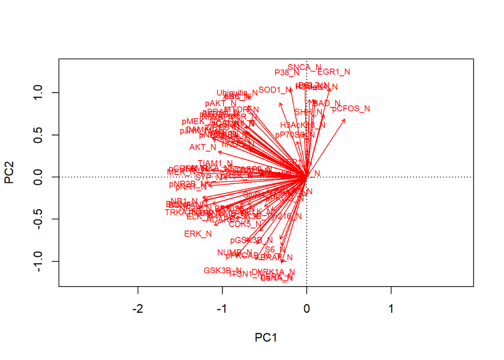

```r
biplot(mouse_pca, scaling = "species", display = "species")
```

Однако, такой график очень тяжело интерпретировать в нашем случае и с нашим количеством признаков. Тем не менее, можно сказать, что по первой компоненте почти все признаки имеют отрицательную нагрузку. Так же построим график ординации с помощью ggplot.

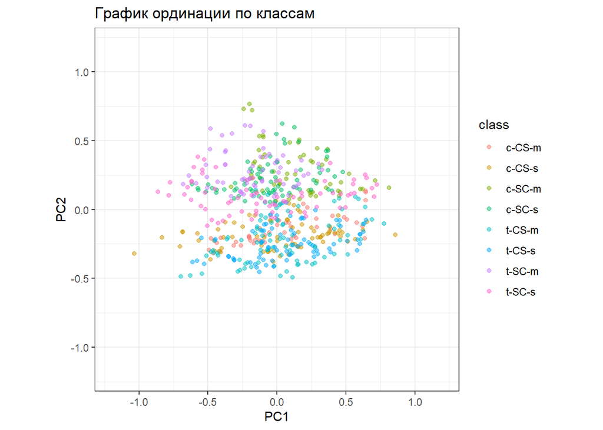

```r
df_scores <- data.frame(data_without_NA,
scores(mouse_pca, display = "sites", choices = c(1, 2, 3), scaling = "sites"))

class_g <- ggplot(df_scores, aes(x = PC1, y = PC2)) + geom_point(aes(color = class), alpha = 0.5) +
coord_equal(xlim = c(-1.2, 1.2), ylim = c(-1.2, 1.2)) + ggtitle(label = "График ординации по классам") + theme_bw()

class_g
```

## 4.2 Вклад каждой компоненты

Посмотрим на собственные числа, а затем построим их график, на котором можно будет посмотреть, какое количество главных компонент вносит существенный вклад.

```r
eigenvals(mouse_pca)
```

```
##       PC1       PC2       PC3       PC4       PC5       PC6       PC7       PC8
## 23.048769 13.358730  7.586460  7.161540  3.282417  3.042340  2.367325  2.255275
##       PC9      PC10      PC11      PC12      PC13      PC14      PC15      PC16
##  1.830755  1.278718  1.111660  0.983128  0.862944  0.700922  0.611169  0.569217
##      PC17      PC18      PC19      PC20      PC21      PC22      PC23      PC24
##  0.520420  0.484876  0.418534  0.399046  0.387367  0.339991  0.319123  0.292254
##      PC25      PC26      PC27      PC28      PC29      PC30      PC31      PC32
##  0.259013  0.241727  0.216222  0.207092  0.182731  0.166772  0.150604  0.136755
##      PC33      PC34      PC35      PC36      PC37      PC38      PC39      PC40
##  0.133922  0.124826  0.123532  0.112486  0.105178  0.096223  0.091371  0.091173
##      PC41      PC42      PC43      PC44      PC45      PC46      PC47      PC48
##  0.082556  0.079101  0.073403  0.072582  0.068041  0.064501  0.063126  0.057797
##      PC49      PC50      PC51      PC52      PC53      PC54      PC55      PC56
##  0.054778  0.052243  0.050093  0.046612  0.045605  0.044344  0.041069  0.040150
##      PC57      PC58      PC59      PC60      PC61      PC62      PC63      PC64
##  0.036550  0.033006  0.032225  0.031406  0.030634  0.028139  0.026891  0.024267
##      PC65      PC66      PC67      PC68      PC69      PC70      PC71      PC72
##  0.021985  0.019966  0.018751  0.018173  0.016725  0.013910  0.012476  0.011562
##      PC73      PC74      PC75      PC76
##  0.011114  0.008883  0.008621  0.006107
```

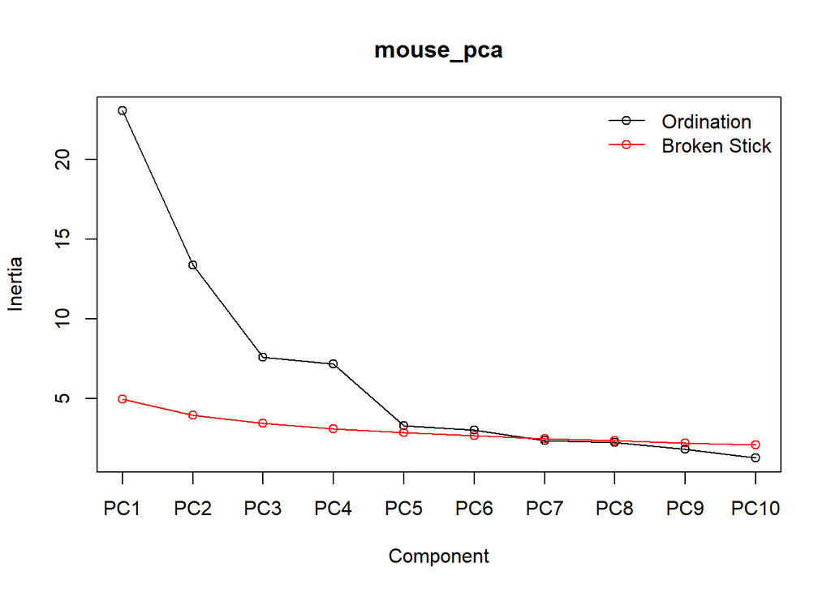

```r
screeplot(mouse_pca, type = "lines", bstick = TRUE)
```

В целом, 6 точек графика собстенных чисел лежат выше модели Broken Stick, поэтому в идеале именно в 6 главных компонент можно “свернуть” наши измерения. Однако, график больше, чем в трех измерениях, интерпретировать и построить будет достаточно затруднительно, поэтому построим для данной модели хотя бы трехмерный график в осях трех первых главных компонент.

## 4.3 Трехмерный график в осях трех первых главных компонент

```r
pca_summary <- prcomp(mouse_data_num, scale=T)
pca3d(pca_summary)
```

```
## [1] 0.2966606 0.2201412 0.1879875
## Creating new device
```

```r
snapshotPCA3d(file="3D_graph.png")
```

[output not shown]